# DNN-Detection-keras

## 实验目的

探究`DNN`在`OFMD`通信系统中进行信道估计和信号检测的能力

## 实验内容

将`DNN`训练模型的结构与传统算法进行比较，以及探究导频长度、激活函数、学习率等参数对性能的影响

## 实验平台

- `OS`: `Manjaro Linux x86_64`
- `Kernel`: `5.4.80-1-MANJARO`
- `Python`: `3.8.6`
- `Jupyter Notebook`: `6.1.4`
- `Matplotlib`: `3.3.3`
- `Numpy`: `1.19.4`
- `Tensorflow`: `2.3.1`
- `Keras`: `2.4.0`

## 实验步骤

运行`run_all`函数，修改其参数值，分别是`CP`, `P`导频长度, `activation`激活函数, `lr`学习率，得到的结果和数据保存在`reslut`文件夹中，其中文件名后缀格式为`[CP]-[P]-[activation]-[lr]`

### 程序的头文件

```python
from tensorflow.keras import layers
from tensorflow.keras import models
from tensorflow.keras import optimizers
from generations import *
```

### 创建神经网络模型

```python
def init_model(activation):
    model = models.Sequential()
    model.add(
        layers.Dense(
            n_hidden_1, activation=activation, input_shape=(payloadBits_per_OFDM * 2,)
        )
    )
    model.add(layers.Dense(n_hidden_2, activation=activation))
    model.add(layers.Dense(n_hidden_3, activation=activation))
    model.add(layers.Dense(n_output, activation="sigmoid"))

    return model
```

### 配置优化器

```python
def config_optimizer(model, lr):
    model.compile(
        optimizer=optimizers.RMSprop(lr=lr), loss="mse", metrics=[bit_err]
    )

    return model
```

### 训练模型

```python
def train_model(CP, P, pilotCarriers, dataCarriers, pilotValue, model):
    history = model.fit(
        training_gen(CP, P, pilotCarriers, dataCarriers, pilotValue, 1000, 20),
        steps_per_epoch=250,
        epochs=100,
        validation_data=validation_gen(
            CP, P, pilotCarriers, dataCarriers, pilotValue, 1000, 20
        ),
        validation_steps=1,
        verbose=2,
    )

    return model, history
```

### 获得相应的数据，以及保存数据

```python
def save_result(history, result_npz):
    loss = history.history["loss"]
    bit_err = history.history["bit_err"]
    val_loss = history.history["val_loss"]
    val_bit_err = history.history["val_bit_err"]

    np.savez(
        result_npz,
        loss=loss,
        bit_err=bit_err,
        val_loss=val_loss,
        val_bit_err=val_bit_err,
    )
```

### 验证经训练得到的模型在各个SNR下的BER性能

```python
def save_evaluate(
    CP, P, pilotCarriers, dataCarriers, pilotValue, model, result_npy
):
    BER = []
    for SNR in range(5, 30, 2):
        y = model.evaluate(
            validation_gen(
                CP, P, pilotCarriers, dataCarriers, pilotValue, 10000, SNR
            ),
            steps=1,
        )  # y=[loss_value, metrics_value]
        BER.append(y[1])

    np.save(result_npy, BER)
```

### 绘制训练ber和验证ber

```python
import matplotlib.pyplot as plt

%matplotlib inline

def draw_training_ber(result_npz, suffix):
    datas = np.load(result_npz)
    loss = datas["loss"]
    bit_err = datas["bit_err"]
    val_loss = datas["val_loss"]
    val_bit_err = datas["val_bit_err"]

    epochs = range(1, len(loss) + 1)

    plt.semilogy(epochs, bit_err, "y", label="Training bit_err")
    plt.semilogy(epochs, val_bit_err, "b", label="Validation bit_err")
    plt.xlabel("epochs")
    plt.ylabel("BER")
    plt.title("Training and validation bit_err")
    plt.legend()
    plt.savefig(os.path.join("result", "bit_err" + suffix + ".jpg"))

    plt.figure()

    return epochs, loss, val_loss
```

### 绘制训练损失和验证损失

```python
def draw_loss(epochs, loss, val_loss, suffix):
    plt.semilogy(epochs, loss, "y", label="Training loss")
    plt.semilogy(epochs, val_loss, "b", label="Validation loss")
    plt.xlabel("epochs")
    plt.ylabel("loss")
    plt.title("Training and validation loss")
    plt.legend()
    plt.savefig(os.path.join("result", "loss" + suffix + ".jpg"))

    plt.figure()
```

### 绘制基于深度学习的信号检测方法的BER性能

```python
def draw_learning_ber(result_npy, suffix):
    BER = np.load(result_npy)
    SNR = range(5, 30, 2)

    plt.semilogy(SNR, BER, "b", label="BER")
    plt.xlabel("SNR(dB)")
    plt.ylabel("BER")
    plt.title("BER of deep learning based approach")
    plt.legend()
    plt.savefig(os.path.join("result", "BER" + suffix + ".jpg"))

    plt.show()
```

```python
def run_all(CP, P, activation, lr):
    suffix = "_" + "-".join([str(CP), str(P), activation, str(lr)])
    result_npz = os.path.join("result", "result" + suffix + ".npz")
    result_npy = "BER" + suffix + ".npy"

    pilotCarriers, dataCarriers = get_carriers(P)
    pilotValue = get_pilot_value(P)

    model = init_model(activation)
    model = config_optimizer(model, lr)
    model, history = train_model(
        CP, P, pilotCarriers, dataCarriers, pilotValue, model
    )

    save_result(history, result_npz)
    save_evaluate(
        CP, P, pilotCarriers, dataCarriers, pilotValue, model, result_npy
    )

    epochs, loss, val_loss = draw_training_ber(result_npz, suffix)
    draw_loss(epochs, loss, val_loss, suffix)
    draw_learning_ber(result_npy, suffix)
```

`CP` = 16, `P` = 64, `activation` = relu, `lr` = 0.001

```
250/250 - 54s - loss: 0.1173 - bit_err: 0.1631 - val_loss: 0.0395 - val_bit_err: 0.0454
250/250 - 54s - loss: 0.0318 - bit_err: 0.0391 - val_loss: 0.0276 - val_bit_err: 0.0343
250/250 - 53s - loss: 0.0193 - bit_err: 0.0247 - val_loss: 0.0166 - val_bit_err: 0.0222
250/250 - 53s - loss: 0.0142 - bit_err: 0.0185 - val_loss: 0.0136 - val_bit_err: 0.0182
250/250 - 46s - loss: 0.0113 - bit_err: 0.0150 - val_loss: 0.0090 - val_bit_err: 0.0125
250/250 - 44s - loss: 0.0096 - bit_err: 0.0129 - val_loss: 0.0110 - val_bit_err: 0.0147
250/250 - 46s - loss: 0.0085 - bit_err: 0.0116 - val_loss: 0.0076 - val_bit_err: 0.0098
250/250 - 51s - loss: 0.0076 - bit_err: 0.0104 - val_loss: 0.0088 - val_bit_err: 0.0114
250/250 - 55s - loss: 0.0070 - bit_err: 0.0096 - val_loss: 0.0068 - val_bit_err: 0.0089
250/250 - 56s - loss: 0.0066 - bit_err: 0.0091 - val_loss: 0.0080 - val_bit_err: 0.0107
250/250 - 58s - loss: 0.0064 - bit_err: 0.0087 - val_loss: 0.0057 - val_bit_err: 0.0077
250/250 - 62s - loss: 0.0060 - bit_err: 0.0082 - val_loss: 0.0056 - val_bit_err: 0.0076
250/250 - 70s - loss: 0.0058 - bit_err: 0.0080 - val_loss: 0.0058 - val_bit_err: 0.0079
250/250 - 68s - loss: 0.0057 - bit_err: 0.0077 - val_loss: 0.0052 - val_bit_err: 0.0071
250/250 - 67s - loss: 0.0056 - bit_err: 0.0075 - val_loss: 0.0059 - val_bit_err: 0.0080
250/250 - 70s - loss: 0.0055 - bit_err: 0.0073 - val_loss: 0.0060 - val_bit_err: 0.0081
250/250 - 76s - loss: 0.0054 - bit_err: 0.0072 - val_loss: 0.0056 - val_bit_err: 0.0074
250/250 - 67s - loss: 0.0052 - bit_err: 0.0070 - val_loss: 0.0043 - val_bit_err: 0.0059
250/250 - 65s - loss: 0.0053 - bit_err: 0.0070 - val_loss: 0.0045 - val_bit_err: 0.0060
250/250 - 64s - loss: 0.0051 - bit_err: 0.0068 - val_loss: 0.0048 - val_bit_err: 0.0066
250/250 - 69s - loss: 0.0051 - bit_err: 0.0068 - val_loss: 0.0047 - val_bit_err: 0.0064
250/250 - 67s - loss: 0.0051 - bit_err: 0.0067 - val_loss: 0.0052 - val_bit_err: 0.0069
250/250 - 67s - loss: 0.0050 - bit_err: 0.0066 - val_loss: 0.0054 - val_bit_err: 0.0073
250/250 - 66s - loss: 0.0050 - bit_err: 0.0066 - val_loss: 0.0052 - val_bit_err: 0.0068
250/250 - 87s - loss: 0.0049 - bit_err: 0.0065 - val_loss: 0.0054 - val_bit_err: 0.0068
250/250 - 71s - loss: 0.0049 - bit_err: 0.0064 - val_loss: 0.0047 - val_bit_err: 0.0064
250/250 - 61s - loss: 0.0049 - bit_err: 0.0064 - val_loss: 0.0049 - val_bit_err: 0.0064
250/250 - 59s - loss: 0.0049 - bit_err: 0.0064 - val_loss: 0.0063 - val_bit_err: 0.0081
250/250 - 55s - loss: 0.0049 - bit_err: 0.0064 - val_loss: 0.0046 - val_bit_err: 0.0058
250/250 - 50s - loss: 0.0049 - bit_err: 0.0064 - val_loss: 0.0038 - val_bit_err: 0.0050
250/250 - 49s - loss: 0.0047 - bit_err: 0.0061 - val_loss: 0.0049 - val_bit_err: 0.0064
250/250 - 63s - loss: 0.0047 - bit_err: 0.0061 - val_loss: 0.0064 - val_bit_err: 0.0082
250/250 - 49s - loss: 0.0048 - bit_err: 0.0062 - val_loss: 0.0048 - val_bit_err: 0.0063
250/250 - 54s - loss: 0.0048 - bit_err: 0.0062 - val_loss: 0.0043 - val_bit_err: 0.0056
250/250 - 49s - loss: 0.0047 - bit_err: 0.0062 - val_loss: 0.0046 - val_bit_err: 0.0063
250/250 - 48s - loss: 0.0047 - bit_err: 0.0061 - val_loss: 0.0047 - val_bit_err: 0.0056
250/250 - 48s - loss: 0.0046 - bit_err: 0.0059 - val_loss: 0.0051 - val_bit_err: 0.0067
250/250 - 58s - loss: 0.0047 - bit_err: 0.0060 - val_loss: 0.0047 - val_bit_err: 0.0060
250/250 - 54s - loss: 0.0046 - bit_err: 0.0060 - val_loss: 0.0038 - val_bit_err: 0.0049
250/250 - 50s - loss: 0.0046 - bit_err: 0.0059 - val_loss: 0.0043 - val_bit_err: 0.0056
```

[output cut: 45 more lines]

```
250/250 - 55s - loss: 0.0041 - bit_err: 0.0053 - val_loss: 0.0046 - val_bit_err: 0.0058
250/250 - 59s - loss: 0.0041 - bit_err: 0.0053 - val_loss: 0.0033 - val_bit_err: 0.0042
250/250 - 62s - loss: 0.0040 - bit_err: 0.0053 - val_loss: 0.0045 - val_bit_err: 0.0057
250/250 - 55s - loss: 0.0040 - bit_err: 0.0052 - val_loss: 0.0043 - val_bit_err: 0.0058
250/250 - 61s - loss: 0.0041 - bit_err: 0.0053 - val_loss: 0.0037 - val_bit_err: 0.0047
250/250 - 64s - loss: 0.0040 - bit_err: 0.0052 - val_loss: 0.0036 - val_bit_err: 0.0048
250/250 - 55s - loss: 0.0040 - bit_err: 0.0052 - val_loss: 0.0039 - val_bit_err: 0.0051
250/250 - 61s - loss: 0.0040 - bit_err: 0.0052 - val_loss: 0.0032 - val_bit_err: 0.0044
250/250 - 59s - loss: 0.0040 - bit_err: 0.0051 - val_loss: 0.0033 - val_bit_err: 0.0046
250/250 - 63s - loss: 0.0040 - bit_err: 0.0052 - val_loss: 0.0046 - val_bit_err: 0.0060
250/250 - 86s - loss: 0.0040 - bit_err: 0.0052 - val_loss: 0.0035 - val_bit_err: 0.0047
250/250 - 85s - loss: 0.0040 - bit_err: 0.0051 - val_loss: 0.0044 - val_bit_err: 0.0061
250/250 - 110s - loss: 0.0039 - bit_err: 0.0051 - val_loss: 0.0036 - val_bit_err: 0.0051
250/250 - 103s - loss: 0.0040 - bit_err: 0.0051 - val_loss: 0.0035 - val_bit_err: 0.0045
250/250 - 79s - loss: 0.0040 - bit_err: 0.0052 - val_loss: 0.0039 - val_bit_err: 0.0052
```

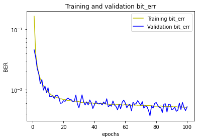

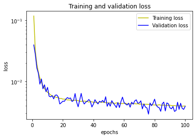

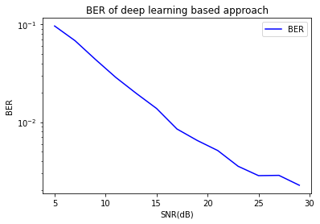

```python
run_all(16, 64, "relu", 0.001)
```

`CP` = 16, `P` = 8, `activation` = relu, `lr` = 0.001

```
250/250 - 46s - loss: 0.1521 - bit_err: 0.2332 - val_loss: 0.0633 - val_bit_err: 0.0798
250/250 - 45s - loss: 0.0473 - bit_err: 0.0619 - val_loss: 0.0401 - val_bit_err: 0.0552
250/250 - 43s - loss: 0.0343 - bit_err: 0.0468 - val_loss: 0.0283 - val_bit_err: 0.0381
250/250 - 43s - loss: 0.0252 - bit_err: 0.0342 - val_loss: 0.0215 - val_bit_err: 0.0290
250/250 - 43s - loss: 0.0198 - bit_err: 0.0271 - val_loss: 0.0202 - val_bit_err: 0.0279
250/250 - 43s - loss: 0.0168 - bit_err: 0.0230 - val_loss: 0.0167 - val_bit_err: 0.0229
250/250 - 43s - loss: 0.0151 - bit_err: 0.0208 - val_loss: 0.0143 - val_bit_err: 0.0194
250/250 - 43s - loss: 0.0139 - bit_err: 0.0191 - val_loss: 0.0144 - val_bit_err: 0.0203
250/250 - 43s - loss: 0.0132 - bit_err: 0.0182 - val_loss: 0.0120 - val_bit_err: 0.0174
250/250 - 43s - loss: 0.0127 - bit_err: 0.0174 - val_loss: 0.0111 - val_bit_err: 0.0155
250/250 - 43s - loss: 0.0122 - bit_err: 0.0167 - val_loss: 0.0123 - val_bit_err: 0.0170
250/250 - 43s - loss: 0.0117 - bit_err: 0.0161 - val_loss: 0.0116 - val_bit_err: 0.0160
250/250 - 43s - loss: 0.0116 - bit_err: 0.0158 - val_loss: 0.0114 - val_bit_err: 0.0159
250/250 - 43s - loss: 0.0111 - bit_err: 0.0152 - val_loss: 0.0133 - val_bit_err: 0.0179
250/250 - 43s - loss: 0.0110 - bit_err: 0.0150 - val_loss: 0.0100 - val_bit_err: 0.0142
250/250 - 44s - loss: 0.0108 - bit_err: 0.0147 - val_loss: 0.0105 - val_bit_err: 0.0144
250/250 - 44s - loss: 0.0107 - bit_err: 0.0145 - val_loss: 0.0100 - val_bit_err: 0.0136
250/250 - 44s - loss: 0.0105 - bit_err: 0.0143 - val_loss: 0.0098 - val_bit_err: 0.0129
250/250 - 44s - loss: 0.0104 - bit_err: 0.0141 - val_loss: 0.0126 - val_bit_err: 0.0171
250/250 - 44s - loss: 0.0103 - bit_err: 0.0140 - val_loss: 0.0093 - val_bit_err: 0.0126
250/250 - 45s - loss: 0.0101 - bit_err: 0.0138 - val_loss: 0.0118 - val_bit_err: 0.0163
250/250 - 45s - loss: 0.0102 - bit_err: 0.0138 - val_loss: 0.0108 - val_bit_err: 0.0148
250/250 - 46s - loss: 0.0100 - bit_err: 0.0136 - val_loss: 0.0102 - val_bit_err: 0.0142
250/250 - 46s - loss: 0.0099 - bit_err: 0.0135 - val_loss: 0.0130 - val_bit_err: 0.0177
250/250 - 48s - loss: 0.0097 - bit_err: 0.0131 - val_loss: 0.0091 - val_bit_err: 0.0123
250/250 - 48s - loss: 0.0098 - bit_err: 0.0132 - val_loss: 0.0118 - val_bit_err: 0.0159
250/250 - 47s - loss: 0.0097 - bit_err: 0.0130 - val_loss: 0.0099 - val_bit_err: 0.0136
250/250 - 48s - loss: 0.0097 - bit_err: 0.0131 - val_loss: 0.0095 - val_bit_err: 0.0135
250/250 - 47s - loss: 0.0096 - bit_err: 0.0130 - val_loss: 0.0089 - val_bit_err: 0.0116
250/250 - 47s - loss: 0.0095 - bit_err: 0.0128 - val_loss: 0.0095 - val_bit_err: 0.0132
250/250 - 47s - loss: 0.0095 - bit_err: 0.0128 - val_loss: 0.0072 - val_bit_err: 0.0099
250/250 - 48s - loss: 0.0095 - bit_err: 0.0128 - val_loss: 0.0096 - val_bit_err: 0.0125
250/250 - 47s - loss: 0.0095 - bit_err: 0.0128 - val_loss: 0.0108 - val_bit_err: 0.0140
250/250 - 47s - loss: 0.0094 - bit_err: 0.0128 - val_loss: 0.0085 - val_bit_err: 0.0112
250/250 - 47s - loss: 0.0092 - bit_err: 0.0125 - val_loss: 0.0095 - val_bit_err: 0.0134
250/250 - 47s - loss: 0.0093 - bit_err: 0.0125 - val_loss: 0.0095 - val_bit_err: 0.0134
250/250 - 48s - loss: 0.0093 - bit_err: 0.0126 - val_loss: 0.0088 - val_bit_err: 0.0121
250/250 - 47s - loss: 0.0092 - bit_err: 0.0124 - val_loss: 0.0093 - val_bit_err: 0.0126
250/250 - 47s - loss: 0.0090 - bit_err: 0.0122 - val_loss: 0.0100 - val_bit_err: 0.0134
250/250 - 47s - loss: 0.0091 - bit_err: 0.0123 - val_loss: 0.0092 - val_bit_err: 0.0126
```

[output cut: 45 more lines]

```
250/250 - 48s - loss: 0.0072 - bit_err: 0.0097 - val_loss: 0.0081 - val_bit_err: 0.0113
250/250 - 47s - loss: 0.0072 - bit_err: 0.0097 - val_loss: 0.0070 - val_bit_err: 0.0094
250/250 - 47s - loss: 0.0072 - bit_err: 0.0097 - val_loss: 0.0070 - val_bit_err: 0.0103
250/250 - 47s - loss: 0.0071 - bit_err: 0.0096 - val_loss: 0.0078 - val_bit_err: 0.0104
250/250 - 48s - loss: 0.0072 - bit_err: 0.0097 - val_loss: 0.0067 - val_bit_err: 0.0089
250/250 - 48s - loss: 0.0071 - bit_err: 0.0096 - val_loss: 0.0069 - val_bit_err: 0.0090
250/250 - 47s - loss: 0.0071 - bit_err: 0.0096 - val_loss: 0.0082 - val_bit_err: 0.0112
250/250 - 47s - loss: 0.0071 - bit_err: 0.0095 - val_loss: 0.0062 - val_bit_err: 0.0086
250/250 - 48s - loss: 0.0070 - bit_err: 0.0095 - val_loss: 0.0068 - val_bit_err: 0.0097
250/250 - 47s - loss: 0.0070 - bit_err: 0.0095 - val_loss: 0.0083 - val_bit_err: 0.0117
250/250 - 48s - loss: 0.0071 - bit_err: 0.0096 - val_loss: 0.0061 - val_bit_err: 0.0079
250/250 - 47s - loss: 0.0070 - bit_err: 0.0094 - val_loss: 0.0050 - val_bit_err: 0.0068
250/250 - 48s - loss: 0.0069 - bit_err: 0.0094 - val_loss: 0.0066 - val_bit_err: 0.0083
250/250 - 47s - loss: 0.0070 - bit_err: 0.0094 - val_loss: 0.0065 - val_bit_err: 0.0088
250/250 - 47s - loss: 0.0070 - bit_err: 0.0095 - val_loss: 0.0062 - val_bit_err: 0.0086
```

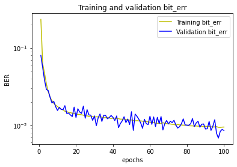

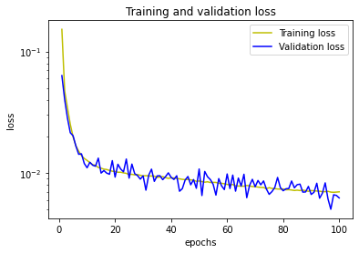

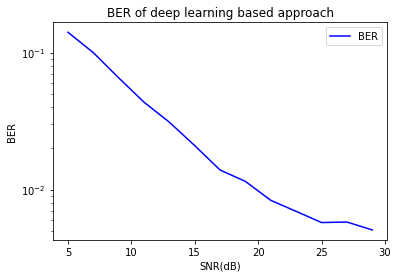

```python
run_all(16, 8, "relu", 0.001)
```

`CP` = 0, `P` = 64, `activation` = relu, `lr` = 0.001

```
250/250 - 51s - loss: 0.1197 - bit_err: 0.1668 - val_loss: 0.0450 - val_bit_err: 0.0526
250/250 - 51s - loss: 0.0351 - bit_err: 0.0439 - val_loss: 0.0232 - val_bit_err: 0.0295
250/250 - 51s - loss: 0.0223 - bit_err: 0.0288 - val_loss: 0.0224 - val_bit_err: 0.0301
250/250 - 51s - loss: 0.0169 - bit_err: 0.0222 - val_loss: 0.0303 - val_bit_err: 0.0383
250/250 - 51s - loss: 0.0140 - bit_err: 0.0188 - val_loss: 0.0131 - val_bit_err: 0.0182
250/250 - 51s - loss: 0.0122 - bit_err: 0.0165 - val_loss: 0.0130 - val_bit_err: 0.0181
250/250 - 51s - loss: 0.0112 - bit_err: 0.0152 - val_loss: 0.0098 - val_bit_err: 0.0138
250/250 - 51s - loss: 0.0103 - bit_err: 0.0140 - val_loss: 0.0089 - val_bit_err: 0.0120
250/250 - 51s - loss: 0.0095 - bit_err: 0.0129 - val_loss: 0.0110 - val_bit_err: 0.0156
250/250 - 51s - loss: 0.0091 - bit_err: 0.0124 - val_loss: 0.0095 - val_bit_err: 0.0126
250/250 - 51s - loss: 0.0087 - bit_err: 0.0118 - val_loss: 0.0106 - val_bit_err: 0.0148
250/250 - 51s - loss: 0.0084 - bit_err: 0.0114 - val_loss: 0.0078 - val_bit_err: 0.0105
250/250 - 51s - loss: 0.0081 - bit_err: 0.0109 - val_loss: 0.0086 - val_bit_err: 0.0111
250/250 - 51s - loss: 0.0080 - bit_err: 0.0108 - val_loss: 0.0072 - val_bit_err: 0.0098
250/250 - 51s - loss: 0.0078 - bit_err: 0.0104 - val_loss: 0.0067 - val_bit_err: 0.0089
250/250 - 51s - loss: 0.0076 - bit_err: 0.0102 - val_loss: 0.0077 - val_bit_err: 0.0102
250/250 - 51s - loss: 0.0075 - bit_err: 0.0101 - val_loss: 0.0087 - val_bit_err: 0.0120
250/250 - 51s - loss: 0.0074 - bit_err: 0.0099 - val_loss: 0.0075 - val_bit_err: 0.0094
250/250 - 51s - loss: 0.0075 - bit_err: 0.0099 - val_loss: 0.0070 - val_bit_err: 0.0091
250/250 - 51s - loss: 0.0073 - bit_err: 0.0097 - val_loss: 0.0069 - val_bit_err: 0.0094
250/250 - 51s - loss: 0.0073 - bit_err: 0.0096 - val_loss: 0.0064 - val_bit_err: 0.0082
250/250 - 51s - loss: 0.0072 - bit_err: 0.0095 - val_loss: 0.0081 - val_bit_err: 0.0108
250/250 - 51s - loss: 0.0071 - bit_err: 0.0094 - val_loss: 0.0066 - val_bit_err: 0.0086
250/250 - 50s - loss: 0.0071 - bit_err: 0.0093 - val_loss: 0.0068 - val_bit_err: 0.0089
250/250 - 50s - loss: 0.0070 - bit_err: 0.0092 - val_loss: 0.0060 - val_bit_err: 0.0084
250/250 - 50s - loss: 0.0070 - bit_err: 0.0092 - val_loss: 0.0071 - val_bit_err: 0.0094
250/250 - 51s - loss: 0.0069 - bit_err: 0.0091 - val_loss: 0.0071 - val_bit_err: 0.0089
250/250 - 51s - loss: 0.0070 - bit_err: 0.0091 - val_loss: 0.0071 - val_bit_err: 0.0092
250/250 - 50s - loss: 0.0069 - bit_err: 0.0090 - val_loss: 0.0074 - val_bit_err: 0.0098
250/250 - 50s - loss: 0.0068 - bit_err: 0.0089 - val_loss: 0.0082 - val_bit_err: 0.0111
250/250 - 51s - loss: 0.0068 - bit_err: 0.0089 - val_loss: 0.0079 - val_bit_err: 0.0102
250/250 - 50s - loss: 0.0068 - bit_err: 0.0089 - val_loss: 0.0060 - val_bit_err: 0.0076
250/250 - 50s - loss: 0.0068 - bit_err: 0.0088 - val_loss: 0.0054 - val_bit_err: 0.0070
250/250 - 50s - loss: 0.0068 - bit_err: 0.0088 - val_loss: 0.0064 - val_bit_err: 0.0086
250/250 - 51s - loss: 0.0067 - bit_err: 0.0087 - val_loss: 0.0057 - val_bit_err: 0.0076
250/250 - 50s - loss: 0.0066 - bit_err: 0.0086 - val_loss: 0.0057 - val_bit_err: 0.0074
250/250 - 51s - loss: 0.0066 - bit_err: 0.0087 - val_loss: 0.0073 - val_bit_err: 0.0095
250/250 - 51s - loss: 0.0067 - bit_err: 0.0087 - val_loss: 0.0056 - val_bit_err: 0.0073
250/250 - 51s - loss: 0.0066 - bit_err: 0.0086 - val_loss: 0.0069 - val_bit_err: 0.0089
250/250 - 50s - loss: 0.0065 - bit_err: 0.0085 - val_loss: 0.0071 - val_bit_err: 0.0092
```

[output cut: 45 more lines]

```
250/250 - 50s - loss: 0.0055 - bit_err: 0.0072 - val_loss: 0.0046 - val_bit_err: 0.0062
250/250 - 50s - loss: 0.0055 - bit_err: 0.0072 - val_loss: 0.0049 - val_bit_err: 0.0064
250/250 - 51s - loss: 0.0055 - bit_err: 0.0072 - val_loss: 0.0060 - val_bit_err: 0.0082
250/250 - 50s - loss: 0.0054 - bit_err: 0.0071 - val_loss: 0.0059 - val_bit_err: 0.0075
250/250 - 50s - loss: 0.0054 - bit_err: 0.0071 - val_loss: 0.0054 - val_bit_err: 0.0071
250/250 - 51s - loss: 0.0054 - bit_err: 0.0071 - val_loss: 0.0059 - val_bit_err: 0.0074
250/250 - 51s - loss: 0.0055 - bit_err: 0.0072 - val_loss: 0.0066 - val_bit_err: 0.0086
250/250 - 51s - loss: 0.0054 - bit_err: 0.0071 - val_loss: 0.0056 - val_bit_err: 0.0074
250/250 - 50s - loss: 0.0053 - bit_err: 0.0070 - val_loss: 0.0050 - val_bit_err: 0.0064
250/250 - 50s - loss: 0.0053 - bit_err: 0.0069 - val_loss: 0.0047 - val_bit_err: 0.0058
250/250 - 50s - loss: 0.0054 - bit_err: 0.0070 - val_loss: 0.0041 - val_bit_err: 0.0051
250/250 - 50s - loss: 0.0053 - bit_err: 0.0070 - val_loss: 0.0058 - val_bit_err: 0.0074
250/250 - 51s - loss: 0.0053 - bit_err: 0.0069 - val_loss: 0.0062 - val_bit_err: 0.0079
250/250 - 51s - loss: 0.0053 - bit_err: 0.0070 - val_loss: 0.0055 - val_bit_err: 0.0074
250/250 - 50s - loss: 0.0053 - bit_err: 0.0070 - val_loss: 0.0056 - val_bit_err: 0.0073
```

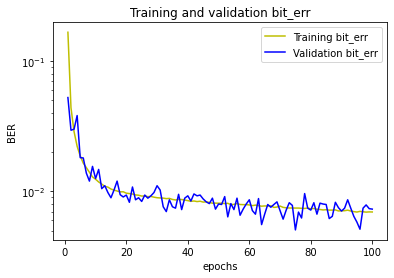

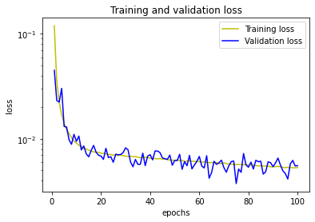

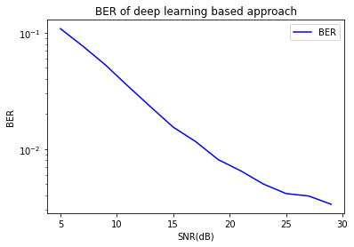

```python
run_all(0, 64, "relu", 0.001)
```

`CP` = 0, `P` = 8, `activation` = relu, `lr` = 0.001

```
250/250 - 51s - loss: 0.1547 - bit_err: 0.2381 - val_loss: 0.0667 - val_bit_err: 0.0832
250/250 - 50s - loss: 0.0513 - bit_err: 0.0673 - val_loss: 0.0409 - val_bit_err: 0.0583
250/250 - 51s - loss: 0.0388 - bit_err: 0.0529 - val_loss: 0.0335 - val_bit_err: 0.0469
250/250 - 51s - loss: 0.0297 - bit_err: 0.0405 - val_loss: 0.0259 - val_bit_err: 0.0346
250/250 - 51s - loss: 0.0244 - bit_err: 0.0335 - val_loss: 0.0244 - val_bit_err: 0.0329
250/250 - 50s - loss: 0.0215 - bit_err: 0.0295 - val_loss: 0.0187 - val_bit_err: 0.0257
250/250 - 51s - loss: 0.0197 - bit_err: 0.0272 - val_loss: 0.0227 - val_bit_err: 0.0316
250/250 - 50s - loss: 0.0187 - bit_err: 0.0257 - val_loss: 0.0161 - val_bit_err: 0.0213
250/250 - 51s - loss: 0.0179 - bit_err: 0.0247 - val_loss: 0.0176 - val_bit_err: 0.0246
250/250 - 50s - loss: 0.0173 - bit_err: 0.0237 - val_loss: 0.0164 - val_bit_err: 0.0217
250/250 - 50s - loss: 0.0169 - bit_err: 0.0231 - val_loss: 0.0179 - val_bit_err: 0.0250
250/250 - 50s - loss: 0.0163 - bit_err: 0.0223 - val_loss: 0.0169 - val_bit_err: 0.0238
250/250 - 51s - loss: 0.0162 - bit_err: 0.0221 - val_loss: 0.0147 - val_bit_err: 0.0196
250/250 - 50s - loss: 0.0158 - bit_err: 0.0216 - val_loss: 0.0156 - val_bit_err: 0.0221
250/250 - 51s - loss: 0.0157 - bit_err: 0.0215 - val_loss: 0.0168 - val_bit_err: 0.0226
250/250 - 51s - loss: 0.0153 - bit_err: 0.0209 - val_loss: 0.0172 - val_bit_err: 0.0241
250/250 - 50s - loss: 0.0153 - bit_err: 0.0208 - val_loss: 0.0132 - val_bit_err: 0.0174
250/250 - 51s - loss: 0.0152 - bit_err: 0.0206 - val_loss: 0.0146 - val_bit_err: 0.0191
250/250 - 50s - loss: 0.0149 - bit_err: 0.0203 - val_loss: 0.0152 - val_bit_err: 0.0206
250/250 - 51s - loss: 0.0148 - bit_err: 0.0201 - val_loss: 0.0132 - val_bit_err: 0.0186
250/250 - 50s - loss: 0.0147 - bit_err: 0.0199 - val_loss: 0.0155 - val_bit_err: 0.0216
250/250 - 50s - loss: 0.0145 - bit_err: 0.0197 - val_loss: 0.0132 - val_bit_err: 0.0179
250/250 - 50s - loss: 0.0144 - bit_err: 0.0194 - val_loss: 0.0154 - val_bit_err: 0.0212
250/250 - 51s - loss: 0.0147 - bit_err: 0.0199 - val_loss: 0.0154 - val_bit_err: 0.0208
250/250 - 51s - loss: 0.0144 - bit_err: 0.0196 - val_loss: 0.0148 - val_bit_err: 0.0203
250/250 - 50s - loss: 0.0142 - bit_err: 0.0192 - val_loss: 0.0133 - val_bit_err: 0.0174
250/250 - 50s - loss: 0.0141 - bit_err: 0.0191 - val_loss: 0.0131 - val_bit_err: 0.0188
250/250 - 51s - loss: 0.0141 - bit_err: 0.0191 - val_loss: 0.0161 - val_bit_err: 0.0222
250/250 - 50s - loss: 0.0140 - bit_err: 0.0189 - val_loss: 0.0151 - val_bit_err: 0.0206
250/250 - 51s - loss: 0.0138 - bit_err: 0.0188 - val_loss: 0.0144 - val_bit_err: 0.0199
250/250 - 50s - loss: 0.0138 - bit_err: 0.0187 - val_loss: 0.0144 - val_bit_err: 0.0195
250/250 - 51s - loss: 0.0138 - bit_err: 0.0188 - val_loss: 0.0121 - val_bit_err: 0.0161
250/250 - 51s - loss: 0.0137 - bit_err: 0.0185 - val_loss: 0.0125 - val_bit_err: 0.0176
250/250 - 51s - loss: 0.0135 - bit_err: 0.0182 - val_loss: 0.0147 - val_bit_err: 0.0205
250/250 - 51s - loss: 0.0135 - bit_err: 0.0182 - val_loss: 0.0132 - val_bit_err: 0.0181
250/250 - 50s - loss: 0.0135 - bit_err: 0.0182 - val_loss: 0.0159 - val_bit_err: 0.0212
250/250 - 51s - loss: 0.0133 - bit_err: 0.0180 - val_loss: 0.0161 - val_bit_err: 0.0213
250/250 - 51s - loss: 0.0134 - bit_err: 0.0181 - val_loss: 0.0132 - val_bit_err: 0.0176
250/250 - 50s - loss: 0.0133 - bit_err: 0.0180 - val_loss: 0.0116 - val_bit_err: 0.0156
250/250 - 50s - loss: 0.0132 - bit_err: 0.0179 - val_loss: 0.0128 - val_bit_err: 0.0169
```

[output cut: 45 more lines]

```
250/250 - 50s - loss: 0.0111 - bit_err: 0.0150 - val_loss: 0.0099 - val_bit_err: 0.0136
250/250 - 51s - loss: 0.0111 - bit_err: 0.0150 - val_loss: 0.0121 - val_bit_err: 0.0165
250/250 - 50s - loss: 0.0112 - bit_err: 0.0151 - val_loss: 0.0085 - val_bit_err: 0.0113
250/250 - 51s - loss: 0.0110 - bit_err: 0.0149 - val_loss: 0.0096 - val_bit_err: 0.0133
250/250 - 50s - loss: 0.0109 - bit_err: 0.0148 - val_loss: 0.0116 - val_bit_err: 0.0154
250/250 - 50s - loss: 0.0110 - bit_err: 0.0148 - val_loss: 0.0104 - val_bit_err: 0.0146
250/250 - 50s - loss: 0.0109 - bit_err: 0.0148 - val_loss: 0.0096 - val_bit_err: 0.0133
250/250 - 50s - loss: 0.0108 - bit_err: 0.0147 - val_loss: 0.0110 - val_bit_err: 0.0148
250/250 - 50s - loss: 0.0107 - bit_err: 0.0145 - val_loss: 0.0111 - val_bit_err: 0.0153
250/250 - 51s - loss: 0.0107 - bit_err: 0.0145 - val_loss: 0.0095 - val_bit_err: 0.0136
250/250 - 50s - loss: 0.0107 - bit_err: 0.0144 - val_loss: 0.0133 - val_bit_err: 0.0182
250/250 - 50s - loss: 0.0108 - bit_err: 0.0146 - val_loss: 0.0102 - val_bit_err: 0.0139
250/250 - 51s - loss: 0.0107 - bit_err: 0.0144 - val_loss: 0.0118 - val_bit_err: 0.0160
250/250 - 50s - loss: 0.0107 - bit_err: 0.0144 - val_loss: 0.0121 - val_bit_err: 0.0158
250/250 - 51s - loss: 0.0105 - bit_err: 0.0142 - val_loss: 0.0109 - val_bit_err: 0.0144
```

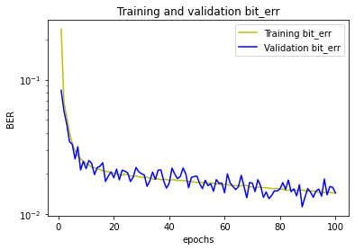

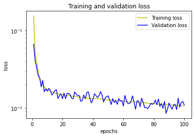

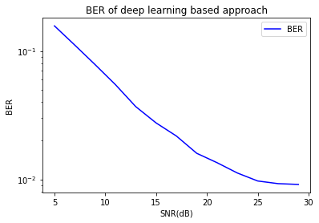

```python
run_all(0, 8, "relu", 0.001)
```

`CP` = 16, `P` = 64, `activation` = relu, `lr` = 0.004

```
250/250 - 48s - loss: 0.1174 - bit_err: 0.1773 - val_loss: 0.0468 - val_bit_err: 0.0638
250/250 - 47s - loss: 0.0435 - bit_err: 0.0577 - val_loss: 0.0275 - val_bit_err: 0.0353
250/250 - 48s - loss: 0.0301 - bit_err: 0.0388 - val_loss: 0.0285 - val_bit_err: 0.0350
250/250 - 48s - loss: 0.0241 - bit_err: 0.0307 - val_loss: 0.0186 - val_bit_err: 0.0244
250/250 - 48s - loss: 0.0206 - bit_err: 0.0258 - val_loss: 0.0201 - val_bit_err: 0.0242
250/250 - 48s - loss: 0.0182 - bit_err: 0.0225 - val_loss: 0.0150 - val_bit_err: 0.0184
250/250 - 48s - loss: 0.0165 - bit_err: 0.0199 - val_loss: 0.0159 - val_bit_err: 0.0188
250/250 - 48s - loss: 0.0156 - bit_err: 0.0185 - val_loss: 0.0162 - val_bit_err: 0.0190
250/250 - 48s - loss: 0.0150 - bit_err: 0.0174 - val_loss: 0.0107 - val_bit_err: 0.0123
250/250 - 48s - loss: 0.0147 - bit_err: 0.0166 - val_loss: 0.0169 - val_bit_err: 0.0186
250/250 - 48s - loss: 0.0146 - bit_err: 0.0163 - val_loss: 0.0135 - val_bit_err: 0.0147
250/250 - 48s - loss: 0.0149 - bit_err: 0.0163 - val_loss: 0.0146 - val_bit_err: 0.0161
250/250 - 48s - loss: 0.0150 - bit_err: 0.0162 - val_loss: 0.0183 - val_bit_err: 0.0194
250/250 - 48s - loss: 0.0152 - bit_err: 0.0162 - val_loss: 0.0184 - val_bit_err: 0.0191
250/250 - 47s - loss: 0.0155 - bit_err: 0.0164 - val_loss: 0.0128 - val_bit_err: 0.0136
250/250 - 47s - loss: 0.0157 - bit_err: 0.0164 - val_loss: 0.0161 - val_bit_err: 0.0166
250/250 - 47s - loss: 0.0160 - bit_err: 0.0166 - val_loss: 0.0190 - val_bit_err: 0.0199
250/250 - 48s - loss: 0.0162 - bit_err: 0.0167 - val_loss: 0.0179 - val_bit_err: 0.0182
250/250 - 48s - loss: 0.0164 - bit_err: 0.0169 - val_loss: 0.0173 - val_bit_err: 0.0178
250/250 - 49s - loss: 0.0169 - bit_err: 0.0174 - val_loss: 0.0186 - val_bit_err: 0.0190
250/250 - 48s - loss: 0.0170 - bit_err: 0.0174 - val_loss: 0.0144 - val_bit_err: 0.0148
250/250 - 48s - loss: 0.0169 - bit_err: 0.0172 - val_loss: 0.0184 - val_bit_err: 0.0188
250/250 - 48s - loss: 0.0171 - bit_err: 0.0174 - val_loss: 0.0162 - val_bit_err: 0.0166
250/250 - 48s - loss: 0.0174 - bit_err: 0.0177 - val_loss: 0.0137 - val_bit_err: 0.0139
250/250 - 47s - loss: 0.0177 - bit_err: 0.0179 - val_loss: 0.0162 - val_bit_err: 0.0165
250/250 - 48s - loss: 0.0180 - bit_err: 0.0183 - val_loss: 0.0204 - val_bit_err: 0.0208
250/250 - 47s - loss: 0.0184 - bit_err: 0.0186 - val_loss: 0.0217 - val_bit_err: 0.0220
250/250 - 48s - loss: 0.0187 - bit_err: 0.0190 - val_loss: 0.0180 - val_bit_err: 0.0183
250/250 - 47s - loss: 0.0190 - bit_err: 0.0193 - val_loss: 0.0160 - val_bit_err: 0.0161
250/250 - 47s - loss: 0.0184 - bit_err: 0.0186 - val_loss: 0.0170 - val_bit_err: 0.0173
250/250 - 47s - loss: 0.0184 - bit_err: 0.0186 - val_loss: 0.0216 - val_bit_err: 0.0217
250/250 - 47s - loss: 0.0191 - bit_err: 0.0193 - val_loss: 0.0220 - val_bit_err: 0.0223
250/250 - 47s - loss: 0.0191 - bit_err: 0.0192 - val_loss: 0.0212 - val_bit_err: 0.0214
250/250 - 47s - loss: 0.0192 - bit_err: 0.0194 - val_loss: 0.0199 - val_bit_err: 0.0199
250/250 - 47s - loss: 0.0192 - bit_err: 0.0193 - val_loss: 0.0174 - val_bit_err: 0.0174
250/250 - 47s - loss: 0.0194 - bit_err: 0.0195 - val_loss: 0.0207 - val_bit_err: 0.0209
250/250 - 47s - loss: 0.0197 - bit_err: 0.0198 - val_loss: 0.0196 - val_bit_err: 0.0197
250/250 - 48s - loss: 0.0196 - bit_err: 0.0198 - val_loss: 0.0167 - val_bit_err: 0.0168
250/250 - 48s - loss: 0.0199 - bit_err: 0.0200 - val_loss: 0.0204 - val_bit_err: 0.0205
250/250 - 47s - loss: 0.0204 - bit_err: 0.0205 - val_loss: 0.0222 - val_bit_err: 0.0223
```

[output cut: 45 more lines]

```
250/250 - 48s - loss: 0.0223 - bit_err: 0.0224 - val_loss: 0.0175 - val_bit_err: 0.0175
250/250 - 47s - loss: 0.0226 - bit_err: 0.0226 - val_loss: 0.0219 - val_bit_err: 0.0219
250/250 - 47s - loss: 0.0225 - bit_err: 0.0226 - val_loss: 0.0265 - val_bit_err: 0.0266
250/250 - 47s - loss: 0.0233 - bit_err: 0.0234 - val_loss: 0.0223 - val_bit_err: 0.0224
250/250 - 47s - loss: 0.0226 - bit_err: 0.0227 - val_loss: 0.0228 - val_bit_err: 0.0229
250/250 - 47s - loss: 0.0234 - bit_err: 0.0235 - val_loss: 0.0259 - val_bit_err: 0.0259
250/250 - 47s - loss: 0.0238 - bit_err: 0.0239 - val_loss: 0.0286 - val_bit_err: 0.0286
250/250 - 47s - loss: 0.0241 - bit_err: 0.0242 - val_loss: 0.0257 - val_bit_err: 0.0257
250/250 - 47s - loss: 0.0234 - bit_err: 0.0234 - val_loss: 0.0239 - val_bit_err: 0.0239
250/250 - 47s - loss: 0.0236 - bit_err: 0.0236 - val_loss: 0.0262 - val_bit_err: 0.0263
250/250 - 47s - loss: 0.0235 - bit_err: 0.0235 - val_loss: 0.0232 - val_bit_err: 0.0232
250/250 - 48s - loss: 0.0231 - bit_err: 0.0231 - val_loss: 0.0232 - val_bit_err: 0.0232
250/250 - 48s - loss: 0.0232 - bit_err: 0.0232 - val_loss: 0.0242 - val_bit_err: 0.0242
250/250 - 48s - loss: 0.0244 - bit_err: 0.0244 - val_loss: 0.0257 - val_bit_err: 0.0257
250/250 - 47s - loss: 0.0235 - bit_err: 0.0235 - val_loss: 0.0216 - val_bit_err: 0.0217
```

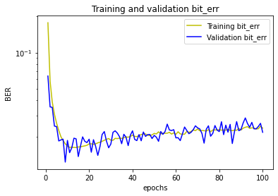

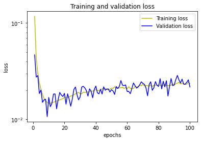

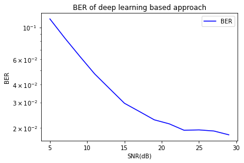

```python
run_all(16, 64, "relu", 0.004)
```

`CP` = 16, `P` = 8, `activation` = relu, `lr` = 0.004

```
250/250 - 48s - loss: 0.1261 - bit_err: 0.1963 - val_loss: 0.0595 - val_bit_err: 0.0842
250/250 - 48s - loss: 0.0497 - bit_err: 0.0685 - val_loss: 0.0406 - val_bit_err: 0.0571
250/250 - 48s - loss: 0.0364 - bit_err: 0.0494 - val_loss: 0.0296 - val_bit_err: 0.0406
250/250 - 48s - loss: 0.0294 - bit_err: 0.0392 - val_loss: 0.0399 - val_bit_err: 0.0494
250/250 - 48s - loss: 0.0262 - bit_err: 0.0344 - val_loss: 0.0241 - val_bit_err: 0.0318
250/250 - 48s - loss: 0.0237 - bit_err: 0.0307 - val_loss: 0.0234 - val_bit_err: 0.0297
250/250 - 48s - loss: 0.0223 - bit_err: 0.0284 - val_loss: 0.0188 - val_bit_err: 0.0247
250/250 - 48s - loss: 0.0209 - bit_err: 0.0262 - val_loss: 0.0243 - val_bit_err: 0.0303
250/250 - 48s - loss: 0.0203 - bit_err: 0.0252 - val_loss: 0.0196 - val_bit_err: 0.0241
250/250 - 48s - loss: 0.0197 - bit_err: 0.0241 - val_loss: 0.0210 - val_bit_err: 0.0253
250/250 - 48s - loss: 0.0195 - bit_err: 0.0233 - val_loss: 0.0203 - val_bit_err: 0.0247
250/250 - 48s - loss: 0.0190 - bit_err: 0.0225 - val_loss: 0.0190 - val_bit_err: 0.0225
250/250 - 48s - loss: 0.0190 - bit_err: 0.0221 - val_loss: 0.0203 - val_bit_err: 0.0234
250/250 - 48s - loss: 0.0188 - bit_err: 0.0216 - val_loss: 0.0215 - val_bit_err: 0.0242
250/250 - 48s - loss: 0.0189 - bit_err: 0.0214 - val_loss: 0.0224 - val_bit_err: 0.0253
250/250 - 48s - loss: 0.0190 - bit_err: 0.0213 - val_loss: 0.0188 - val_bit_err: 0.0213
250/250 - 48s - loss: 0.0194 - bit_err: 0.0215 - val_loss: 0.0190 - val_bit_err: 0.0206
250/250 - 48s - loss: 0.0195 - bit_err: 0.0212 - val_loss: 0.0177 - val_bit_err: 0.0196
250/250 - 48s - loss: 0.0196 - bit_err: 0.0212 - val_loss: 0.0184 - val_bit_err: 0.0194
250/250 - 48s - loss: 0.0199 - bit_err: 0.0213 - val_loss: 0.0211 - val_bit_err: 0.0222
250/250 - 48s - loss: 0.0202 - bit_err: 0.0214 - val_loss: 0.0196 - val_bit_err: 0.0204
250/250 - 48s - loss: 0.0204 - bit_err: 0.0214 - val_loss: 0.0236 - val_bit_err: 0.0243
250/250 - 48s - loss: 0.0206 - bit_err: 0.0216 - val_loss: 0.0194 - val_bit_err: 0.0201
250/250 - 47s - loss: 0.0209 - bit_err: 0.0217 - val_loss: 0.0234 - val_bit_err: 0.0244
250/250 - 48s - loss: 0.0208 - bit_err: 0.0216 - val_loss: 0.0198 - val_bit_err: 0.0203
250/250 - 47s - loss: 0.0210 - bit_err: 0.0218 - val_loss: 0.0208 - val_bit_err: 0.0215
250/250 - 48s - loss: 0.0215 - bit_err: 0.0222 - val_loss: 0.0218 - val_bit_err: 0.0225
250/250 - 48s - loss: 0.0219 - bit_err: 0.0225 - val_loss: 0.0229 - val_bit_err: 0.0234
250/250 - 47s - loss: 0.0220 - bit_err: 0.0226 - val_loss: 0.0217 - val_bit_err: 0.0224
250/250 - 47s - loss: 0.0224 - bit_err: 0.0229 - val_loss: 0.0243 - val_bit_err: 0.0247
250/250 - 48s - loss: 0.0224 - bit_err: 0.0229 - val_loss: 0.0265 - val_bit_err: 0.0270
250/250 - 48s - loss: 0.0229 - bit_err: 0.0233 - val_loss: 0.0207 - val_bit_err: 0.0211
250/250 - 48s - loss: 0.0230 - bit_err: 0.0233 - val_loss: 0.0254 - val_bit_err: 0.0258
250/250 - 47s - loss: 0.0231 - bit_err: 0.0235 - val_loss: 0.0248 - val_bit_err: 0.0253
250/250 - 48s - loss: 0.0227 - bit_err: 0.0231 - val_loss: 0.0210 - val_bit_err: 0.0211
250/250 - 48s - loss: 0.0232 - bit_err: 0.0235 - val_loss: 0.0219 - val_bit_err: 0.0223
250/250 - 47s - loss: 0.0236 - bit_err: 0.0239 - val_loss: 0.0211 - val_bit_err: 0.0215
250/250 - 48s - loss: 0.0237 - bit_err: 0.0240 - val_loss: 0.0251 - val_bit_err: 0.0254
250/250 - 47s - loss: 0.0237 - bit_err: 0.0240 - val_loss: 0.0226 - val_bit_err: 0.0228
250/250 - 48s - loss: 0.0239 - bit_err: 0.0241 - val_loss: 0.0246 - val_bit_err: 0.0249
```

[output cut: 45 more lines]

```
250/250 - 48s - loss: 0.0274 - bit_err: 0.0275 - val_loss: 0.0307 - val_bit_err: 0.0308
250/250 - 47s - loss: 0.0281 - bit_err: 0.0282 - val_loss: 0.0265 - val_bit_err: 0.0266
250/250 - 48s - loss: 0.0277 - bit_err: 0.0278 - val_loss: 0.0258 - val_bit_err: 0.0258
250/250 - 48s - loss: 0.0285 - bit_err: 0.0286 - val_loss: 0.0282 - val_bit_err: 0.0282
250/250 - 48s - loss: 0.0279 - bit_err: 0.0279 - val_loss: 0.0291 - val_bit_err: 0.0291
250/250 - 47s - loss: 0.0274 - bit_err: 0.0274 - val_loss: 0.0287 - val_bit_err: 0.0288
250/250 - 47s - loss: 0.0283 - bit_err: 0.0284 - val_loss: 0.0287 - val_bit_err: 0.0288
250/250 - 47s - loss: 0.0280 - bit_err: 0.0281 - val_loss: 0.0300 - val_bit_err: 0.0300
250/250 - 47s - loss: 0.0282 - bit_err: 0.0282 - val_loss: 0.0305 - val_bit_err: 0.0306
250/250 - 48s - loss: 0.0281 - bit_err: 0.0282 - val_loss: 0.0286 - val_bit_err: 0.0288
250/250 - 48s - loss: 0.0282 - bit_err: 0.0283 - val_loss: 0.0266 - val_bit_err: 0.0267
250/250 - 48s - loss: 0.0281 - bit_err: 0.0282 - val_loss: 0.0262 - val_bit_err: 0.0263
250/250 - 48s - loss: 0.0282 - bit_err: 0.0283 - val_loss: 0.0290 - val_bit_err: 0.0291
250/250 - 47s - loss: 0.0284 - bit_err: 0.0285 - val_loss: 0.0264 - val_bit_err: 0.0265
250/250 - 47s - loss: 0.0279 - bit_err: 0.0280 - val_loss: 0.0315 - val_bit_err: 0.0316
```

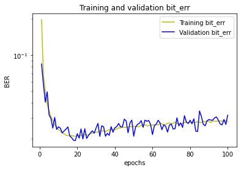

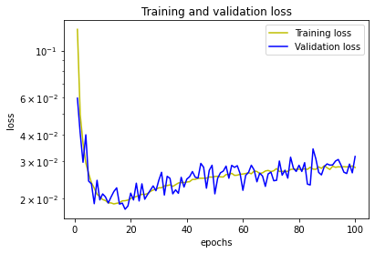

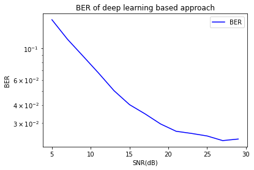

```python
run_all(16, 8, "relu", 0.004)
```

`CP` = 16, `P` = 64, `activation` = sigmoid, `lr` = 0.001

```
250/250 - 44s - loss: 0.2470 - bit_err: 0.4619 - val_loss: 0.2305 - val_bit_err: 0.3438
250/250 - 44s - loss: 0.1941 - bit_err: 0.2564 - val_loss: 0.1632 - val_bit_err: 0.2041
250/250 - 44s - loss: 0.1327 - bit_err: 0.1449 - val_loss: 0.1068 - val_bit_err: 0.1018
250/250 - 44s - loss: 0.0870 - bit_err: 0.0760 - val_loss: 0.0722 - val_bit_err: 0.0619
250/250 - 44s - loss: 0.0566 - bit_err: 0.0448 - val_loss: 0.0478 - val_bit_err: 0.0403
250/250 - 44s - loss: 0.0396 - bit_err: 0.0316 - val_loss: 0.0324 - val_bit_err: 0.0243
250/250 - 44s - loss: 0.0287 - bit_err: 0.0227 - val_loss: 0.0251 - val_bit_err: 0.0213
250/250 - 44s - loss: 0.0216 - bit_err: 0.0175 - val_loss: 0.0190 - val_bit_err: 0.0154
250/250 - 44s - loss: 0.0170 - bit_err: 0.0143 - val_loss: 0.0158 - val_bit_err: 0.0139
250/250 - 44s - loss: 0.0139 - bit_err: 0.0123 - val_loss: 0.0127 - val_bit_err: 0.0107
250/250 - 44s - loss: 0.0117 - bit_err: 0.0108 - val_loss: 0.0111 - val_bit_err: 0.0101
250/250 - 44s - loss: 0.0101 - bit_err: 0.0098 - val_loss: 0.0084 - val_bit_err: 0.0076
250/250 - 44s - loss: 0.0089 - bit_err: 0.0089 - val_loss: 0.0094 - val_bit_err: 0.0102
250/250 - 45s - loss: 0.0080 - bit_err: 0.0084 - val_loss: 0.0077 - val_bit_err: 0.0078
250/250 - 44s - loss: 0.0074 - bit_err: 0.0079 - val_loss: 0.0072 - val_bit_err: 0.0079
250/250 - 45s - loss: 0.0068 - bit_err: 0.0075 - val_loss: 0.0064 - val_bit_err: 0.0068
250/250 - 44s - loss: 0.0063 - bit_err: 0.0071 - val_loss: 0.0064 - val_bit_err: 0.0073
250/250 - 45s - loss: 0.0060 - bit_err: 0.0069 - val_loss: 0.0061 - val_bit_err: 0.0065
250/250 - 46s - loss: 0.0057 - bit_err: 0.0067 - val_loss: 0.0053 - val_bit_err: 0.0062
250/250 - 46s - loss: 0.0054 - bit_err: 0.0064 - val_loss: 0.0054 - val_bit_err: 0.0064
250/250 - 47s - loss: 0.0052 - bit_err: 0.0063 - val_loss: 0.0059 - val_bit_err: 0.0077
250/250 - 48s - loss: 0.0050 - bit_err: 0.0061 - val_loss: 0.0043 - val_bit_err: 0.0053
250/250 - 48s - loss: 0.0048 - bit_err: 0.0060 - val_loss: 0.0046 - val_bit_err: 0.0058
250/250 - 48s - loss: 0.0047 - bit_err: 0.0058 - val_loss: 0.0045 - val_bit_err: 0.0056
250/250 - 48s - loss: 0.0046 - bit_err: 0.0058 - val_loss: 0.0048 - val_bit_err: 0.0063
250/250 - 48s - loss: 0.0045 - bit_err: 0.0057 - val_loss: 0.0051 - val_bit_err: 0.0068
250/250 - 48s - loss: 0.0044 - bit_err: 0.0056 - val_loss: 0.0050 - val_bit_err: 0.0067
250/250 - 48s - loss: 0.0043 - bit_err: 0.0055 - val_loss: 0.0037 - val_bit_err: 0.0043
250/250 - 48s - loss: 0.0042 - bit_err: 0.0054 - val_loss: 0.0049 - val_bit_err: 0.0066
250/250 - 48s - loss: 0.0041 - bit_err: 0.0054 - val_loss: 0.0038 - val_bit_err: 0.0049
250/250 - 48s - loss: 0.0041 - bit_err: 0.0053 - val_loss: 0.0033 - val_bit_err: 0.0046
250/250 - 48s - loss: 0.0040 - bit_err: 0.0052 - val_loss: 0.0034 - val_bit_err: 0.0046
250/250 - 48s - loss: 0.0040 - bit_err: 0.0052 - val_loss: 0.0029 - val_bit_err: 0.0041
250/250 - 48s - loss: 0.0040 - bit_err: 0.0052 - val_loss: 0.0028 - val_bit_err: 0.0034
250/250 - 48s - loss: 0.0039 - bit_err: 0.0051 - val_loss: 0.0042 - val_bit_err: 0.0056
250/250 - 48s - loss: 0.0039 - bit_err: 0.0051 - val_loss: 0.0036 - val_bit_err: 0.0045
250/250 - 48s - loss: 0.0039 - bit_err: 0.0051 - val_loss: 0.0039 - val_bit_err: 0.0051
250/250 - 48s - loss: 0.0038 - bit_err: 0.0050 - val_loss: 0.0027 - val_bit_err: 0.0034
250/250 - 48s - loss: 0.0038 - bit_err: 0.0050 - val_loss: 0.0042 - val_bit_err: 0.0052
250/250 - 48s - loss: 0.0037 - bit_err: 0.0049 - val_loss: 0.0030 - val_bit_err: 0.0036
```

[output cut: 45 more lines]

```
250/250 - 49s - loss: 0.0033 - bit_err: 0.0044 - val_loss: 0.0042 - val_bit_err: 0.0056
250/250 - 50s - loss: 0.0032 - bit_err: 0.0043 - val_loss: 0.0035 - val_bit_err: 0.0048
250/250 - 50s - loss: 0.0033 - bit_err: 0.0044 - val_loss: 0.0022 - val_bit_err: 0.0030
250/250 - 57s - loss: 0.0032 - bit_err: 0.0043 - val_loss: 0.0029 - val_bit_err: 0.0038
250/250 - 50s - loss: 0.0032 - bit_err: 0.0043 - val_loss: 0.0026 - val_bit_err: 0.0033
250/250 - 50s - loss: 0.0033 - bit_err: 0.0044 - val_loss: 0.0043 - val_bit_err: 0.0056
250/250 - 50s - loss: 0.0032 - bit_err: 0.0043 - val_loss: 0.0039 - val_bit_err: 0.0052
250/250 - 49s - loss: 0.0032 - bit_err: 0.0043 - val_loss: 0.0031 - val_bit_err: 0.0043
250/250 - 57s - loss: 0.0033 - bit_err: 0.0044 - val_loss: 0.0029 - val_bit_err: 0.0038
250/250 - 78s - loss: 0.0033 - bit_err: 0.0044 - val_loss: 0.0034 - val_bit_err: 0.0046
250/250 - 57s - loss: 0.0032 - bit_err: 0.0043 - val_loss: 0.0029 - val_bit_err: 0.0039
250/250 - 67s - loss: 0.0032 - bit_err: 0.0043 - val_loss: 0.0033 - val_bit_err: 0.0046
250/250 - 63s - loss: 0.0032 - bit_err: 0.0043 - val_loss: 0.0024 - val_bit_err: 0.0031
250/250 - 64s - loss: 0.0032 - bit_err: 0.0043 - val_loss: 0.0024 - val_bit_err: 0.0037
250/250 - 65s - loss: 0.0031 - bit_err: 0.0042 - val_loss: 0.0042 - val_bit_err: 0.0058
```

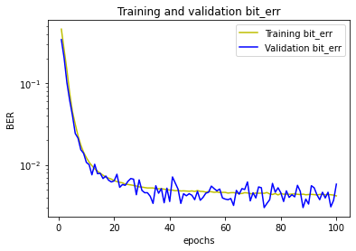

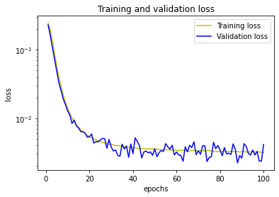

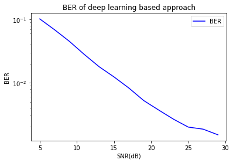

```python
run_all(16, 64, "sigmoid", 0.001)
```

`CP` = 16, `P` = 8, `activation` = sigmoid, `lr` = 0.001

```
250/250 - 49s - loss: 0.2505 - bit_err: 0.4994 - val_loss: 0.2499 - val_bit_err: 0.4891
250/250 - 49s - loss: 0.2382 - bit_err: 0.4248 - val_loss: 0.2168 - val_bit_err: 0.3347
250/250 - 46s - loss: 0.1859 - bit_err: 0.2532 - val_loss: 0.1527 - val_bit_err: 0.1764
250/250 - 52s - loss: 0.1208 - bit_err: 0.1187 - val_loss: 0.0941 - val_bit_err: 0.0798
250/250 - 47s - loss: 0.0770 - bit_err: 0.0665 - val_loss: 0.0661 - val_bit_err: 0.0609
250/250 - 58s - loss: 0.0542 - bit_err: 0.0494 - val_loss: 0.0483 - val_bit_err: 0.0472
250/250 - 60s - loss: 0.0413 - bit_err: 0.0394 - val_loss: 0.0378 - val_bit_err: 0.0361
250/250 - 61s - loss: 0.0324 - bit_err: 0.0312 - val_loss: 0.0296 - val_bit_err: 0.0292
250/250 - 56s - loss: 0.0267 - bit_err: 0.0264 - val_loss: 0.0245 - val_bit_err: 0.0245
250/250 - 58s - loss: 0.0226 - bit_err: 0.0229 - val_loss: 0.0215 - val_bit_err: 0.0224
250/250 - 64s - loss: 0.0196 - bit_err: 0.0204 - val_loss: 0.0174 - val_bit_err: 0.0180
250/250 - 67s - loss: 0.0176 - bit_err: 0.0190 - val_loss: 0.0167 - val_bit_err: 0.0182
250/250 - 61s - loss: 0.0160 - bit_err: 0.0177 - val_loss: 0.0156 - val_bit_err: 0.0173
250/250 - 64s - loss: 0.0146 - bit_err: 0.0167 - val_loss: 0.0133 - val_bit_err: 0.0141
250/250 - 60s - loss: 0.0136 - bit_err: 0.0158 - val_loss: 0.0149 - val_bit_err: 0.0183
250/250 - 70s - loss: 0.0130 - bit_err: 0.0154 - val_loss: 0.0103 - val_bit_err: 0.0115
250/250 - 70s - loss: 0.0123 - bit_err: 0.0148 - val_loss: 0.0127 - val_bit_err: 0.0156
250/250 - 65s - loss: 0.0117 - bit_err: 0.0142 - val_loss: 0.0118 - val_bit_err: 0.0138
250/250 - 50s - loss: 0.0114 - bit_err: 0.0141 - val_loss: 0.0118 - val_bit_err: 0.0144
250/250 - 60s - loss: 0.0110 - bit_err: 0.0138 - val_loss: 0.0116 - val_bit_err: 0.0146
250/250 - 72s - loss: 0.0108 - bit_err: 0.0137 - val_loss: 0.0108 - val_bit_err: 0.0139
250/250 - 68s - loss: 0.0104 - bit_err: 0.0133 - val_loss: 0.0104 - val_bit_err: 0.0139
250/250 - 67s - loss: 0.0102 - bit_err: 0.0131 - val_loss: 0.0105 - val_bit_err: 0.0138
250/250 - 61s - loss: 0.0099 - bit_err: 0.0128 - val_loss: 0.0104 - val_bit_err: 0.0142
250/250 - 59s - loss: 0.0097 - bit_err: 0.0127 - val_loss: 0.0096 - val_bit_err: 0.0126
250/250 - 52s - loss: 0.0097 - bit_err: 0.0126 - val_loss: 0.0079 - val_bit_err: 0.0097
250/250 - 49s - loss: 0.0096 - bit_err: 0.0126 - val_loss: 0.0102 - val_bit_err: 0.0131
250/250 - 57s - loss: 0.0094 - bit_err: 0.0125 - val_loss: 0.0080 - val_bit_err: 0.0109
250/250 - 63s - loss: 0.0094 - bit_err: 0.0125 - val_loss: 0.0099 - val_bit_err: 0.0129
250/250 - 49s - loss: 0.0091 - bit_err: 0.0121 - val_loss: 0.0091 - val_bit_err: 0.0116
250/250 - 65s - loss: 0.0091 - bit_err: 0.0121 - val_loss: 0.0099 - val_bit_err: 0.0132
250/250 - 64s - loss: 0.0091 - bit_err: 0.0121 - val_loss: 0.0088 - val_bit_err: 0.0124
250/250 - 61s - loss: 0.0089 - bit_err: 0.0119 - val_loss: 0.0091 - val_bit_err: 0.0123
250/250 - 62s - loss: 0.0089 - bit_err: 0.0119 - val_loss: 0.0094 - val_bit_err: 0.0123
250/250 - 65s - loss: 0.0088 - bit_err: 0.0118 - val_loss: 0.0079 - val_bit_err: 0.0105
250/250 - 68s - loss: 0.0088 - bit_err: 0.0118 - val_loss: 0.0092 - val_bit_err: 0.0127
250/250 - 65s - loss: 0.0087 - bit_err: 0.0117 - val_loss: 0.0088 - val_bit_err: 0.0119
250/250 - 73s - loss: 0.0086 - bit_err: 0.0116 - val_loss: 0.0086 - val_bit_err: 0.0116
250/250 - 62s - loss: 0.0088 - bit_err: 0.0118 - val_loss: 0.0070 - val_bit_err: 0.0092
250/250 - 70s - loss: 0.0086 - bit_err: 0.0116 - val_loss: 0.0092 - val_bit_err: 0.0121
```

[output cut: 45 more lines]

```
250/250 - 48s - loss: 0.0076 - bit_err: 0.0103 - val_loss: 0.0087 - val_bit_err: 0.0117
250/250 - 48s - loss: 0.0075 - bit_err: 0.0101 - val_loss: 0.0081 - val_bit_err: 0.0113
250/250 - 48s - loss: 0.0076 - bit_err: 0.0102 - val_loss: 0.0091 - val_bit_err: 0.0119
250/250 - 48s - loss: 0.0075 - bit_err: 0.0101 - val_loss: 0.0068 - val_bit_err: 0.0090
250/250 - 48s - loss: 0.0074 - bit_err: 0.0100 - val_loss: 0.0085 - val_bit_err: 0.0114
250/250 - 48s - loss: 0.0076 - bit_err: 0.0103 - val_loss: 0.0076 - val_bit_err: 0.0100
250/250 - 48s - loss: 0.0075 - bit_err: 0.0101 - val_loss: 0.0070 - val_bit_err: 0.0101
250/250 - 48s - loss: 0.0074 - bit_err: 0.0100 - val_loss: 0.0077 - val_bit_err: 0.0104
250/250 - 48s - loss: 0.0074 - bit_err: 0.0100 - val_loss: 0.0079 - val_bit_err: 0.0105
250/250 - 48s - loss: 0.0075 - bit_err: 0.0102 - val_loss: 0.0058 - val_bit_err: 0.0079
250/250 - 48s - loss: 0.0075 - bit_err: 0.0101 - val_loss: 0.0073 - val_bit_err: 0.0096
250/250 - 48s - loss: 0.0074 - bit_err: 0.0100 - val_loss: 0.0075 - val_bit_err: 0.0107
250/250 - 48s - loss: 0.0073 - bit_err: 0.0099 - val_loss: 0.0081 - val_bit_err: 0.0109
250/250 - 48s - loss: 0.0074 - bit_err: 0.0100 - val_loss: 0.0072 - val_bit_err: 0.0099
250/250 - 48s - loss: 0.0074 - bit_err: 0.0100 - val_loss: 0.0060 - val_bit_err: 0.0086
```

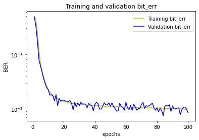

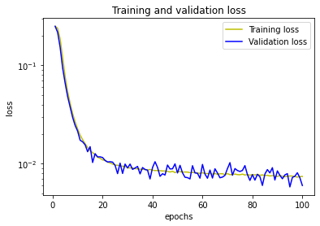

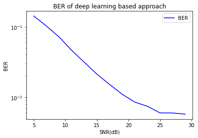

```python
run_all(16, 8, "sigmoid", 0.001)
```